# Heidi_kvinneordsekk_korpus

## Preamble

Run these if notebook is in a new environment, otherwise just skip to `Import modules`

#### Boot cell

Skip if `module_update.py` is in same folder as notebook, next cell downloads this file which in turn will download other files.

```python
!curl -s "https://raw.githubusercontent.com/Yoonsen/Modules/master/module_update.py" > "module_update.py"
```

#### Get essentials

Import text and graph modules for analysis, and css for display

```python
from module_update import update, css, code_toggle
```

```python
css()
```

```python
code_toggle()
```

# Import modules

Aktiver cellen nedenfor for å få alt til å virke.

```python
update('nbtext', overwrite=True)
import nbtext as nb
from IPython.display import HTML
import requests
from bs4 import BeautifulSoup

import pandas as pd
```

Updated file `D:\Documents\notebøker\nbtext.py`

Grunnlagsdata

```python
kvinder = """kvinne, kvinnen, kvinner, kvinnene, kvinnerne, kvinnes, kvinnens, kvinners, kvinnenes, kvinnernes, kvinde, kvinden, kvinder, kvinderne, kvindens, kvindes, kvindernes, kvinders, kvindelige, kvindelig, kvindeligt, kvindene, kvindeme, kvindekøn, kvindenes, kvindemes, kvindc, kvindcr, kvindcn, kvindcns, kvindcs, kvindcrnes, kvindcrnc, kvindcrs, kvindcrncs, kvindclighed, kvindcligheden, kuindc, kuindcr, kuindcn, kuindcs, kuindcrne, kuindcns, kuinde, kuinder, kuinden, kuinderne, kuindens, kuinders, kuindes, kvindelighed, kvindeligt, kvindelighedens, kvindeligheden, kvindeligheds, kvindelighed, kvindclige, kvindelighcd, kvindeligked, kvindeligbed, qvinde, qvinden, qvinder, qvinderne, qvindene, qvindelig, qvindelige, qvindelighed, quinde, quinden, quinder, qvinderne, qvindene, quindelig, quindelighed, qvindcn, quindcn, qvindclig, quindclig, qvindcr, quindcr, qvindcrne, qvindene, quindcrne, quindcne, qvindclighcd, quindclighcd, qvindelighcd, quindelighcd, qvindclighed, quindclighcd, jente, jenten, jenta, jenter, jentene, jenterne, jentas, jentens, jentes, jenters, jentenes, jenterne, jenternes, jcnte, jcnten, jcnterne, pike, piken, piker, pikene, pikerne, pikes, pikens, pikers, pikenes, pikernes, pikebarn, pikebørn, pige, pigen, piger, pigene, pigerne, piges, pigens, pigers, pigenes, pigernes, pigebarn, pigebarnet, pigebørn, pigc, pigcn, pigcr, pigcne, pigcrne, pigcs, pigcbarn, pigcbarnet, heltinne, heltinnen, heltinner, heltinnene, heltinnens, hcltinnen, heltinde, heltinden, heltinder, heltindene, heltinderne, heltindens, heltindc, tjenerinne, tjenerinnen, tjenerinde, tjenerinden, tjcnerinde, tjcncrinde, tjcnerinden, tjcncrinden, tjcncrindcn, fristerinne, fristerinnen, fristerinnens, fristerinde, fristerinden, fristerindens, fristcrinde, fristcrinden, fristcrindcn, kone, konen, koncn, hustru, fruentimmer, fruentimmeret, fruentimmere, fruentimmerne, fruentimmernc, fruentimmers, fruentimmerets, fruentimmeraktig, fruentimmeragtig, fruentimmerlig, fruentimmerlige, fruentimmerfølelser, fruentimre, fruentimret, fruentimrene, hun, henne, hcnne, hennc, hcnnc,qvindekjønnet, qvindekjonnet, qvindckjonnet, quindckjonnet, quindekjønnet, quindekjonnet, quindckjonnet,qvindekjonn, qvindckjonn, quindekjonn, quindckjonn,  beskjørtede, bcskjørtede, bcskjørtcde, bcskjortcde, beskjortcde, bcskjortede, beskjortede fruentimmernetheder, fruentimmcrncdhcer, frucntimmcrncdhcdcr, husmødrene, husmodrene, husmoder, husmor, husmodrcne, mor, moder, moderlig, modre, modrcne, modrc, modcrlig, modcrlighcden, modcrlighed, moderlighed, modcrlighcd, telegrafistinde, telegrafistinder, telegrafistinderne, telcgrafistinde, tclcgrafistinde, tclcgrafistindcr, telcgrafistindcrne, lcererinde, lærerinde, lcercrinde, lcercrinder, lcererinderne, lcercrindene, Kvinne, Kvinnen, Kvinner, Kvinnene, Kvinnerne, Kvinnes, Kvinnens, Kvinners, Kvinnenes, Kvinnernes, Kvinde, Kvinden, Kvinder, Kvinderne, Kvindens, Kvindes, Kvindernes, Kvinders, Kvindelige, Kvindelig, Kvindeligt, Kvindene, Kvindeme, Kvindekøn, Kvindenes, Kvindemes, Kvindc, Kvindcr, Kvindcn, Kvindcns, Kvindcs, Kvindcrnes, Kvindcrnc, Kvindcrs, Kvindcrncs, Kvindclighed, Kvindcligheden, Kuindc, Kuindcr, Kuindcn, Kuindcs, Kuindcrne, Kuindcns, Kuinde, Kuinder, Kuinden, Kuinderne, Kuindens, Kuinders, Kuindes, Kvindelighed, Kvindelighedens, Kvindeligheden, Kvindeligheds, Kvindclige, Kvindelighcd, Kvindeligked, Kvindeligbed,  Qvinde, Qvinden, Qvinder, Qvinderne, Qvindene, Qvindelig, Qvindelige, Qvindelighed, Quinde, Quinden, Quinder, Qvinderne, Qvindene, Quindelig, Quindelighed, Qvindcn, Quindcn, Qvindclig, quindclig, qvindcr, quindcr, qvindcrne, qvindene, quindcrne, quindcne, qvindclighcd, Quindclighcd, Qvindelighcd, Quindelighcd, Qvindclighed, Quindclighcd, Jente, Jenten, Jenta, Jenter, Jentene, Jenterne, Jentas, Jentens, Jentes, Jenters, Jentenes, Jenternes, Jcnte, Jcnten, Jcnterne, Pike, Piken, Piker, Pikene, Pikerne, Pikes, Pikens, Pikers, Pikenes, Pikernes, Pikebarn, Pikebørn, Pige, Pigen, Piger, Pigene, Pigerne, Piges, Pigens, Pigers, Pigenes, Pigernes, Pigebarn, Pigebarnet, Pigebørn, Pigc, Pigcn, Pigcr, Pigcne, Pigcrne, Pigcs, Pigcbarn, Pigcbarnet, Heltinne, Heltinnen, Heltinner, Heltinnene, Heltinnens, Hcltinnen, Heltinde, Heltinden, Heltinder, Heltindene, Heltinderne, Heltindens, Heltindc, Tjenerinne, Tjenerinnen, Tjenerinde, Tjenerinden, Tjcnerinde, Tjcncrinde, Tjcnerinden, Tjcncrinden, Tjcncrindcn, Fristerinne, Fristerinnen, Fristerinnens, Fristerinde, Fristerinden, Fristerindens, Fristcrinde, Fristcrinden, Fristcrindcn, Kone, Konen, Koncn, Hustru, Fruentimmer, Fruentimmeret, Fruentimmere, Fruentimmerne, Fruentimmernc, Fruentimmers, Fruentimmerets, Fruentimmeraktig, Fruentimmeragtig, Fruentimmerlig, Fruentimmerlige, Fruentimmerfølelser, Fruentimre, Fruentimret, Fruentimrene, Hun, Henne, Hcnne, Hennc, Hcnnc, Qvindekjønnet, Qvindekjonnet, Qvindckjonnet, Quindckjonnet, Quindekjønnet, Quindekjonnet, Quindckjonnet,Qvindekjonn, Qvindckjonn, Quindekjonn, Quindckjonn,  Beskjørtede, Bcskjørtede, Bcskjørtcde, Bcskjortcde, Beskjortcde, Bcskjortede, Beskjortede Fruentimmernetheder, Fruentimmcrncdhcer, Frucntimmcrncdhcdcr, Husmødrene, Husmodrene, Husmoder, Husmor, Husmodrcne, Mor, Moder, Moderlig, Modre, Modrcne, Modrc, Modcrlig, Modcrlighcden, Modcrlighed, Moderlighed, Modcrlighcd, Telegrafistinde, Telegrafistinder, Telegrafistinderne, Telcgrafistinde, Tclcgrafistinde, Tclcgrafistindcr, Telcgrafistindcrne, Lcererinde, Lærerinde, Lcercrinde, Lcercrinder, Lcererinderne, Lcercrindene"""
qvinder = [x.strip() for x in kvinder.split(',')]
```

```python
qvinder
```

```
['kvinne',
 'kvinnen',
 'kvinner',
 'kvinnene',
 'kvinnerne',
 'kvinnes',
 'kvinnens',
 'kvinners',
 'kvinnenes',
 'kvinnernes',
 'kvinde',
 'kvinden',
 'kvinder',
 'kvinderne',
 'kvindens',
 'kvindes',
 'kvindernes',
 'kvinders',
 'kvindelige',
 'kvindelig',
 'kvindeligt',
 'kvindene',
 'kvindeme',
 'kvindekøn',
 'kvindenes',
 'kvindemes',
 'kvindc',
 'kvindcr',
 'kvindcn',
 'kvindcns',
 'kvindcs',
 'kvindcrnes',
 'kvindcrnc',
 'kvindcrs',
 'kvindcrncs',
 'kvindclighed',
 'kvindcligheden',
 'kuindc',
 'kuindcr',
 'kuindcn',
```

[output cut: 430 more lines]

```
 'Moderlighed',
 'Modcrlighcd',
 'Telegrafistinde',
 'Telegrafistinder',
 'Telegrafistinderne',
 'Telcgrafistinde',
 'Tclcgrafistinde',
 'Tclcgrafistindcr',
 'Telcgrafistindcrne',
 'Lcererinde',
 'Lærerinde',
 'Lcercrinde',
 'Lcercrinder',
 'Lcererinderne',
 'Lcercrindene']
```

Antall ord i ordsekken

```python
len(qvinder)
```

```
485
```

## Hent data for hvert ord

Den her tar et par minutter. Tid til å lage en kopp te!

```python
df = []
for qv in qvinder:
    #print(qv)
    x = nb.unigram(qv, period=(1830, 1900), media='bok')
    if not x.empty:
        x.columns = [qv]
        df.append(x)
```

### Summer opp totalen over ord, og for år (nedenfor)

```python
tot = pd.concat(df, sort=False, axis='columns').fillna(0)
```

```python
tot
```

|  | kvinne | kvinnen | kvinner | kvinnene | kvinnerne | kvinnes | kvinnens | kvinners | kvinnernes | kvinde | ... | Modrcne | Modrc | Moderlighed | Telegrafistinde | Telegrafistinder | Lcererinde | Lærerinde | Lcercrinde | Lcercrinder | Lcererinderne |
| --- | --- | --- | --- | --- | --- | --- | --- | --- | --- | --- | --- | --- | --- | --- | --- | --- | --- | --- | --- | --- | --- |
| 1830 | 0.0 | 0.0 | 0.0 | 0.0 | 0.0 | 0.0 | 0.0 | 0.0 | 0.0 | 0.0 | ... | 0.0 | 0.0 | 0.0 | 0.0 | 0.0 | 0.0 | 1.0 | 0.0 | 0.0 | 0.0 |
| 1831 | 0.0 | 0.0 | 0.0 | 0.0 | 0.0 | 0.0 | 0.0 | 0.0 | 0.0 | 0.0 | ... | 0.0 | 0.0 | 0.0 | 0.0 | 0.0 | 0.0 | 0.0 | 0.0 | 0.0 | 0.0 |
| 1832 | 0.0 | 0.0 | 0.0 | 0.0 | 0.0 | 0.0 | 0.0 | 0.0 | 0.0 | 5.0 | ... | 0.0 | 0.0 | 0.0 | 0.0 | 0.0 | 1.0 | 2.0 | 0.0 | 0.0 | 0.0 |
| 1833 | 0.0 | 0.0 | 0.0 | 0.0 | 0.0 | 0.0 | 0.0 | 0.0 | 0.0 | 0.0 | ... | 0.0 | 1.0 | 0.0 | 0.0 | 0.0 | 0.0 | 1.0 | 0.0 | 0.0 | 0.0 |
| 1834 | 0.0 | 0.0 | 0.0 | 0.0 | 0.0 | 0.0 | 0.0 | 0.0 | 0.0 | 0.0 | ... | 2.0 | 0.0 | 0.0 | 0.0 | 0.0 | 0.0 | 2.0 | 0.0 | 0.0 | 0.0 |
| 1835 | 0.0 | 0.0 | 0.0 | 0.0 | 0.0 | 0.0 | 0.0 | 0.0 | 0.0 | 0.0 | ... | 0.0 | 0.0 | 0.0 | 0.0 | 0.0 | 0.0 | 0.0 | 0.0 | 0.0 | 0.0 |
| 1836 | 0.0 | 0.0 | 0.0 | 0.0 | 0.0 | 0.0 | 0.0 | 0.0 | 0.0 | 0.0 | ... | 0.0 | 0.0 | 0.0 | 0.0 | 0.0 | 0.0 | 0.0 | 0.0 | 0.0 | 0.0 |
| 1837 | 0.0 | 0.0 | 0.0 | 0.0 | 0.0 | 0.0 | 0.0 | 0.0 | 0.0 | 0.0 | ... | 0.0 | 0.0 | 0.0 | 0.0 | 0.0 | 0.0 | 0.0 | 0.0 | 0.0 | 0.0 |
| 1838 | 0.0 | 0.0 | 0.0 | 0.0 | 0.0 | 0.0 | 0.0 | 0.0 | 0.0 | 1.0 | ... | 0.0 | 0.0 | 0.0 | 0.0 | 0.0 | 2.0 | 0.0 | 0.0 | 0.0 | 0.0 |
| 1839 | 0.0 | 0.0 | 0.0 | 0.0 | 0.0 | 0.0 | 0.0 | 0.0 | 0.0 | 0.0 | ... | 0.0 | 0.0 | 0.0 | 0.0 | 0.0 | 0.0 | 0.0 | 0.0 | 0.0 | 0.0 |
| 1840 | 0.0 | 0.0 | 0.0 | 0.0 | 0.0 | 0.0 | 0.0 | 0.0 | 0.0 | 0.0 | ... | 0.0 | 0.0 | 0.0 | 0.0 | 0.0 | 1.0 | 0.0 | 0.0 | 0.0 | 0.0 |
| 1841 | 0.0 | 0.0 | 0.0 | 0.0 | 0.0 | 0.0 | 0.0 | 0.0 | 0.0 | 0.0 | ... | 0.0 | 2.0 | 0.0 | 0.0 | 0.0 | 2.0 | 3.0 | 0.0 | 0.0 | 0.0 |
| 1842 | 0.0 | 0.0 | 0.0 | 0.0 | 0.0 | 0.0 | 0.0 | 0.0 | 0.0 | 0.0 | ... | 1.0 | 0.0 | 0.0 | 0.0 | 0.0 | 1.0 | 1.0 | 0.0 | 0.0 | 0.0 |
| 1843 | 0.0 | 0.0 | 0.0 | 0.0 | 0.0 | 0.0 | 0.0 | 0.0 | 0.0 | 0.0 | ... | 0.0 | 0.0 | 0.0 | 0.0 | 0.0 | 0.0 | 0.0 | 0.0 | 0.0 | 0.0 |
| 1844 | 0.0 | 0.0 | 0.0 | 0.0 | 0.0 | 0.0 | 0.0 | 0.0 | 0.0 | 1.0 | ... | 3.0 | 3.0 | 0.0 | 0.0 | 0.0 | 1.0 | 2.0 | 0.0 | 0.0 | 0.0 |
| 1845 | 0.0 | 0.0 | 0.0 | 0.0 | 0.0 | 0.0 | 0.0 | 0.0 | 0.0 | 1.0 | ... | 0.0 | 2.0 | 0.0 | 0.0 | 0.0 | 0.0 | 0.0 | 0.0 | 0.0 | 0.0 |
| 1846 | 0.0 | 0.0 | 0.0 | 0.0 | 0.0 | 0.0 | 0.0 | 0.0 | 0.0 | 1.0 | ... | 0.0 | 2.0 | 0.0 | 0.0 | 0.0 | 0.0 | 0.0 | 0.0 | 0.0 | 0.0 |
| 1847 | 1.0 | 0.0 | 0.0 | 0.0 | 0.0 | 0.0 | 0.0 | 0.0 | 0.0 | 0.0 | ... | 2.0 | 10.0 | 0.0 | 0.0 | 0.0 | 0.0 | 0.0 | 0.0 | 0.0 | 0.0 |
| 1848 | 1.0 | 0.0 | 0.0 | 0.0 | 0.0 | 0.0 | 0.0 | 0.0 | 0.0 | 0.0 | ... | 0.0 | 2.0 | 0.0 | 0.0 | 0.0 | 1.0 | 0.0 | 0.0 | 0.0 | 0.0 |
| 1849 | 2.0 | 0.0 | 0.0 | 0.0 | 0.0 | 0.0 | 0.0 | 0.0 | 0.0 | 3.0 | ... | 2.0 | 2.0 | 0.0 | 0.0 | 0.0 | 1.0 | 0.0 | 0.0 | 0.0 | 0.0 |
| 1850 | 0.0 | 0.0 | 0.0 | 0.0 | 0.0 | 0.0 | 0.0 | 0.0 | 0.0 | 0.0 | ... | 0.0 | 2.0 | 0.0 | 0.0 | 0.0 | 3.0 | 4.0 | 0.0 | 0.0 | 0.0 |
| 1851 | 0.0 | 0.0 | 0.0 | 0.0 | 0.0 | 0.0 | 0.0 | 0.0 | 0.0 | 1.0 | ... | 0.0 | 2.0 | 0.0 | 0.0 | 0.0 | 2.0 | 6.0 | 0.0 | 0.0 | 0.0 |
| 1852 | 0.0 | 0.0 | 0.0 | 0.0 | 0.0 | 0.0 | 0.0 | 0.0 | 0.0 | 0.0 | ... | 1.0 | 0.0 | 0.0 | 0.0 | 0.0 | 4.0 | 1.0 | 1.0 | 0.0 | 0.0 |
| 1853 | 8.0 | 0.0 | 0.0 | 0.0 | 0.0 | 0.0 | 0.0 | 0.0 | 0.0 | 5.0 | ... | 0.0 | 1.0 | 1.0 | 0.0 | 0.0 | 3.0 | 1.0 | 0.0 | 0.0 | 0.0 |
| 1854 | 0.0 | 0.0 | 0.0 | 0.0 | 0.0 | 0.0 | 0.0 | 0.0 | 0.0 | 1.0 | ... | 0.0 | 0.0 | 0.0 | 0.0 | 0.0 | 3.0 | 1.0 | 1.0 | 1.0 | 0.0 |
| 1855 | 0.0 | 0.0 | 0.0 | 0.0 | 0.0 | 0.0 | 0.0 | 0.0 | 0.0 | 1.0 | ... | 0.0 | 1.0 | 0.0 | 0.0 | 0.0 | 0.0 | 0.0 | 0.0 | 0.0 | 0.0 |
| 1856 | 0.0 | 0.0 | 1.0 | 0.0 | 0.0 | 0.0 | 0.0 | 0.0 | 0.0 | 8.0 | ... | 1.0 | 0.0 | 1.0 | 0.0 | 0.0 | 3.0 | 1.0 | 0.0 | 0.0 | 1.0 |
| 1857 | 0.0 | 0.0 | 0.0 | 0.0 | 0.0 | 0.0 | 0.0 | 0.0 | 0.0 | 3.0 | ... | 1.0 | 0.0 | 0.0 | 0.0 | 0.0 | 3.0 | 2.0 | 0.0 | 0.0 | 0.0 |
| 1858 | 4.0 | 0.0 | 0.0 | 0.0 | 0.0 | 0.0 | 0.0 | 0.0 | 1.0 | 21.0 | ... | 0.0 | 1.0 | 0.0 | 0.0 | 0.0 | 2.0 | 0.0 | 0.0 | 0.0 | 0.0 |
| 1859 | 0.0 | 0.0 | 0.0 | 0.0 | 0.0 | 0.0 | 0.0 | 0.0 | 0.0 | 1.0 | ... | 0.0 | 1.0 | 0.0 | 0.0 | 0.0 | 4.0 | 2.0 | 0.0 | 0.0 | 0.0 |
| ... | ... | ... | ... | ... | ... | ... | ... | ... | ... | ... | ... | ... | ... | ... | ... | ... | ... | ... | ... | ... | ... |
| 1871 | 4.0 | 0.0 | 0.0 | 0.0 | 0.0 | 1.0 | 0.0 | 0.0 | 0.0 | 17.0 | ... | 0.0 | 0.0 | 0.0 | 0.0 | 0.0 | 3.0 | 2.0 | 0.0 | 0.0 | 0.0 |
| 1872 | 0.0 | 0.0 | 0.0 | 0.0 | 0.0 | 0.0 | 0.0 | 0.0 | 0.0 | 19.0 | ... | 0.0 | 1.0 | 1.0 | 0.0 | 0.0 | 29.0 | 0.0 | 1.0 | 0.0 | 6.0 |
| 1873 | 0.0 | 0.0 | 0.0 | 0.0 | 0.0 | 1.0 | 0.0 | 0.0 | 0.0 | 61.0 | ... | 0.0 | 1.0 | 1.0 | 0.0 | 0.0 | 10.0 | 41.0 | 1.0 | 0.0 | 7.0 |
| 1874 | 10.0 | 0.0 | 1.0 | 0.0 | 0.0 | 0.0 | 0.0 | 0.0 | 0.0 | 66.0 | ... | 0.0 | 0.0 | 0.0 | 0.0 | 0.0 | 1.0 | 5.0 | 0.0 | 0.0 | 0.0 |
| 1875 | 0.0 | 0.0 | 0.0 | 0.0 | 0.0 | 0.0 | 0.0 | 0.0 | 0.0 | 16.0 | ... | 0.0 | 0.0 | 0.0 | 0.0 | 0.0 | 3.0 | 10.0 | 0.0 | 0.0 | 1.0 |
| 1876 | 4.0 | 2.0 | 5.0 | 0.0 | 1.0 | 0.0 | 1.0 | 0.0 | 0.0 | 41.0 | ... | 0.0 | 0.0 | 1.0 | 1.0 | 0.0 | 5.0 | 14.0 | 0.0 | 0.0 | 0.0 |
| 1877 | 7.0 | 2.0 | 5.0 | 1.0 | 2.0 | 0.0 | 0.0 | 0.0 | 0.0 | 85.0 | ... | 0.0 | 1.0 | 0.0 | 2.0 | 0.0 | 2.0 | 23.0 | 0.0 | 0.0 | 0.0 |
| 1878 | 5.0 | 0.0 | 3.0 | 0.0 | 1.0 | 0.0 | 0.0 | 0.0 | 0.0 | 86.0 | ... | 0.0 | 1.0 | 0.0 | 0.0 | 0.0 | 17.0 | 11.0 | 0.0 | 0.0 | 1.0 |
| 1879 | 8.0 | 0.0 | 6.0 | 0.0 | 1.0 | 0.0 | 0.0 | 0.0 | 0.0 | 102.0 | ... | 0.0 | 0.0 | 0.0 | 1.0 | 0.0 | 5.0 | 5.0 | 0.0 | 0.0 | 0.0 |
| 1880 | 18.0 | 8.0 | 7.0 | 0.0 | 2.0 | 2.0 | 2.0 | 0.0 | 0.0 | 101.0 | ... | 0.0 | 1.0 | 0.0 | 0.0 | 0.0 | 10.0 | 45.0 | 0.0 | 0.0 | 0.0 |
| 1881 | 39.0 | 8.0 | 1.0 | 0.0 | 0.0 | 0.0 | 0.0 | 0.0 | 0.0 | 87.0 | ... | 0.0 | 0.0 | 2.0 | 1.0 | 0.0 | 11.0 | 33.0 | 0.0 | 0.0 | 0.0 |
| 1882 | 0.0 | 0.0 | 1.0 | 0.0 | 0.0 | 0.0 | 0.0 | 0.0 | 0.0 | 128.0 | ... | 0.0 | 4.0 | 2.0 | 0.0 | 0.0 | 15.0 | 21.0 | 0.0 | 0.0 | 1.0 |
| 1883 | 12.0 | 7.0 | 5.0 | 0.0 | 3.0 | 0.0 | 0.0 | 0.0 | 0.0 | 117.0 | ... | 0.0 | 0.0 | 1.0 | 0.0 | 0.0 | 10.0 | 52.0 | 0.0 | 0.0 | 0.0 |
| 1884 | 26.0 | 15.0 | 21.0 | 0.0 | 7.0 | 1.0 | 13.0 | 1.0 | 0.0 | 172.0 | ... | 0.0 | 0.0 | 0.0 | 4.0 | 0.0 | 9.0 | 18.0 | 0.0 | 0.0 | 0.0 |
| 1885 | 16.0 | 3.0 | 16.0 | 2.0 | 4.0 | 1.0 | 0.0 | 0.0 | 1.0 | 286.0 | ... | 0.0 | 0.0 | 0.0 | 1.0 | 1.0 | 8.0 | 78.0 | 0.0 | 0.0 | 0.0 |
| 1886 | 4.0 | 4.0 | 5.0 | 0.0 | 1.0 | 0.0 | 1.0 | 0.0 | 0.0 | 329.0 | ... | 0.0 | 0.0 | 1.0 | 0.0 | 1.0 | 11.0 | 104.0 | 0.0 | 0.0 | 0.0 |
| 1887 | 6.0 | 0.0 | 5.0 | 0.0 | 0.0 | 0.0 | 0.0 | 0.0 | 0.0 | 563.0 | ... | 0.0 | 1.0 | 0.0 | 0.0 | 2.0 | 15.0 | 34.0 | 0.0 | 1.0 | 1.0 |
| 1888 | 5.0 | 1.0 | 3.0 | 0.0 | 0.0 | 0.0 | 0.0 | 0.0 | 0.0 | 580.0 | ... | 0.0 | 0.0 | 0.0 | 0.0 | 0.0 | 13.0 | 18.0 | 0.0 | 0.0 | 0.0 |
| 1889 | 17.0 | 1.0 | 11.0 | 0.0 | 0.0 | 0.0 | 1.0 | 0.0 | 2.0 | 421.0 | ... | 0.0 | 2.0 | 1.0 | 1.0 | 0.0 | 4.0 | 30.0 | 1.0 | 0.0 | 0.0 |
| 1890 | 8.0 | 4.0 | 11.0 | 0.0 | 8.0 | 2.0 | 3.0 | 0.0 | 0.0 | 632.0 | ... | 0.0 | 0.0 | 0.0 | 1.0 | 0.0 | 8.0 | 40.0 | 0.0 | 0.0 | 2.0 |
| 1891 | 80.0 | 18.0 | 82.0 | 0.0 | 28.0 | 8.0 | 8.0 | 8.0 | 10.0 | 500.0 | ... | 0.0 | 0.0 | 0.0 | 0.0 | 0.0 | 7.0 | 16.0 | 0.0 | 0.0 | 0.0 |
| 1892 | 24.0 | 1.0 | 4.0 | 0.0 | 0.0 | 0.0 | 2.0 | 0.0 | 0.0 | 738.0 | ... | 0.0 | 0.0 | 0.0 | 0.0 | 0.0 | 7.0 | 38.0 | 0.0 | 0.0 | 0.0 |
| 1893 | 10.0 | 1.0 | 4.0 | 0.0 | 2.0 | 1.0 | 0.0 | 0.0 | 1.0 | 419.0 | ... | 0.0 | 0.0 | 2.0 | 0.0 | 5.0 | 10.0 | 83.0 | 0.0 | 0.0 | 0.0 |
| 1894 | 33.0 | 7.0 | 15.0 | 0.0 | 0.0 | 0.0 | 1.0 | 0.0 | 0.0 | 735.0 | ... | 0.0 | 0.0 | 2.0 | 2.0 | 2.0 | 11.0 | 79.0 | 0.0 | 0.0 | 0.0 |
| 1895 | 6.0 | 0.0 | 6.0 | 0.0 | 0.0 | 0.0 | 0.0 | 0.0 | 0.0 | 631.0 | ... | 0.0 | 0.0 | 3.0 | 1.0 | 0.0 | 14.0 | 68.0 | 0.0 | 0.0 | 0.0 |
| 1896 | 20.0 | 1.0 | 16.0 | 0.0 | 3.0 | 3.0 | 0.0 | 0.0 | 0.0 | 774.0 | ... | 0.0 | 0.0 | 1.0 | 2.0 | 0.0 | 11.0 | 53.0 | 0.0 | 0.0 | 0.0 |
| 1897 | 25.0 | 2.0 | 11.0 | 0.0 | 0.0 | 0.0 | 0.0 | 1.0 | 0.0 | 632.0 | ... | 0.0 | 1.0 | 1.0 | 0.0 | 1.0 | 1.0 | 45.0 | 0.0 | 0.0 | 0.0 |
| 1898 | 7.0 | 0.0 | 1.0 | 0.0 | 0.0 | 0.0 | 0.0 | 0.0 | 0.0 | 1367.0 | ... | 1.0 | 0.0 | 0.0 | 4.0 | 0.0 | 1.0 | 64.0 | 0.0 | 0.0 | 0.0 |
| 1899 | 28.0 | 0.0 | 6.0 | 0.0 | 0.0 | 1.0 | 0.0 | 0.0 | 0.0 | 859.0 | ... | 0.0 | 0.0 | 1.0 | 0.0 | 0.0 | 13.0 | 79.0 | 1.0 | 0.0 | 1.0 |
| 1900 | 22.0 | 0.0 | 4.0 | 0.0 | 0.0 | 0.0 | 1.0 | 0.0 | 0.0 | 961.0 | ... | 0.0 | 1.0 | 5.0 | 0.0 | 0.0 | 15.0 | 38.0 | 1.0 | 0.0 | 0.0 |

71 rows × 337 columns

Se på totalsummer og sett grenser for øver og nedre. Spennet er såpass stort at mye domineres av de ordene med størst frekvens

```python
totsum = tot.sum()
```

Delsummer og studier av dem. Her er det snakk om totalantall over hele perioden. Delmengder er knyttet til et parameter, bare endre på tallet for `totsum`. Maxen her er på flere tusen. Du kan også endre på selve relasjonen, og skrive `totsum` > 300, for eksempel. Trykk på code_toggle-knappen for å se koden.

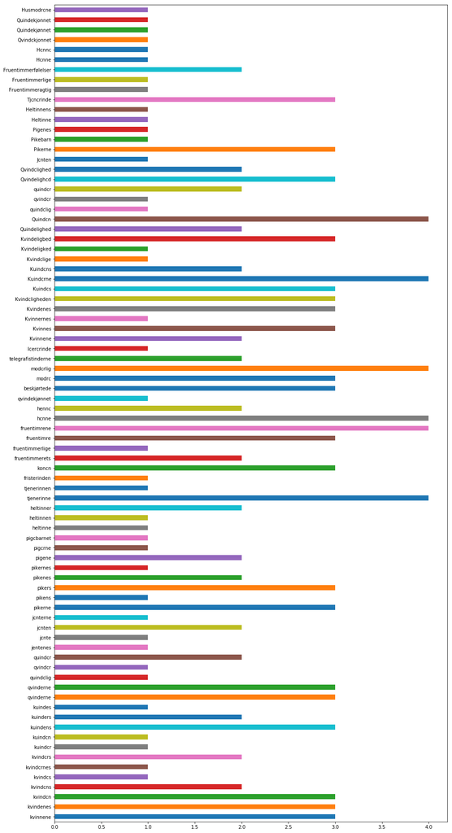

```python
subsum = totsum[totsum < 5]
subsum.plot(kind='barh', figsize = (15, int(len(subsum)*0.4)));
```

## Summasjoner pr. år - her totalfrekvens:

```python
annosum = tot.sum(axis=1)
```

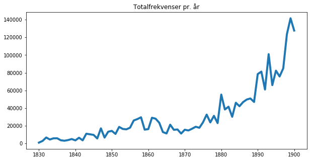

```python
annosum.plot(figsize=(10, 5), lw=4, title="Totalfrekvenser pr. år");
```

## Relativfrekvens, relativ til punktueringer

```python
punktueringer = ". , og i".split()
df_punkt = pd.concat([nb.frame(nb.unigram(p, period=(1830, 1900), media='bok'), p) for p in punktueringer], axis='columns', sort=False)
```

```python
df_punkt_sum = nb.frame(df_punkt.sum(axis=1), 'punkt')
```

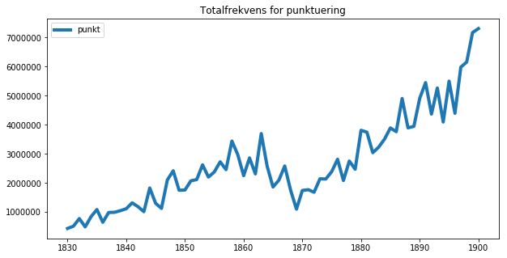

```python
df_punkt_sum.plot(figsize = (10,5), lw=4, title = "Totalfrekvens for punktuering");
```

## Plot over kvinneord relativ til punktueringer.

Omtrent like bra som (om ikke bedre enn) relativfrekvens sammenlignet med totalen. Punktueringene har et stabilt prosentvis antall av totalen.

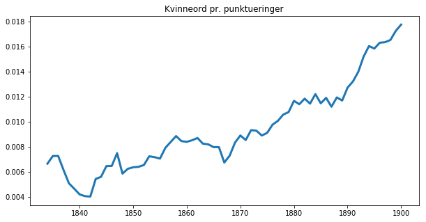

```python
(annosum/df_punkt_sum['punkt']).rolling(window=5).mean().plot(figsize=(10, 5), lw=3, title="Kvinneord pr. punktueringer");
```

# Samme trend om pronomene tas ut

```python
anno_uten_hun = tot[list(set(tot.columns) - set(['Hun', 'hun','hende', 'Hende', 'hendes', 'Hendes']))]
```

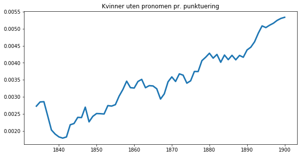

```python
(anno_uten_hun.sum(axis=1)/df_punkt_sum['punkt']).rolling(window=5).mean().plot(figsize=(10, 5), lw=3, title= "Kvinner uten pronomen pr. punktuering");
```